# How are peoples interactions with their instagram feeds?

## What is this story about?

This visual data story uses 40 responses from a google form to explore how peoples interactions are with their instagram feed, with a focus on what content they receive and how this affects the time they spend using the app and if they could change anything.

## What content do people see on their feeds?

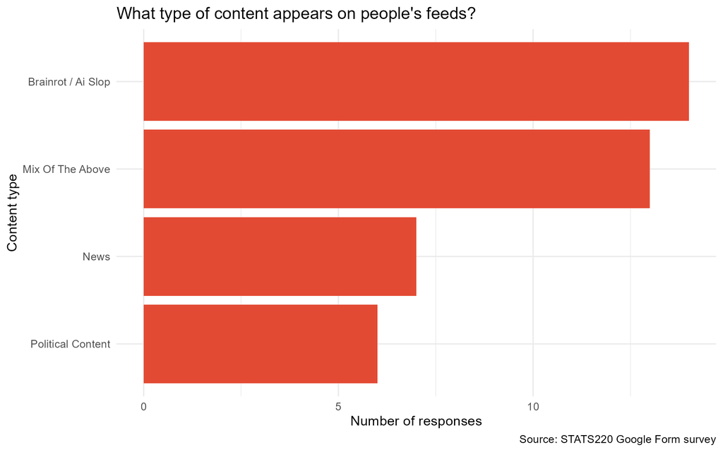

The plot above shows varying categories of content types that people typically encounter, and how its roughly distributed among other categories. For example, AI content has the most number of responses showing that the algorithm tends to show things relating to this

## How much time do people spend scrolling?

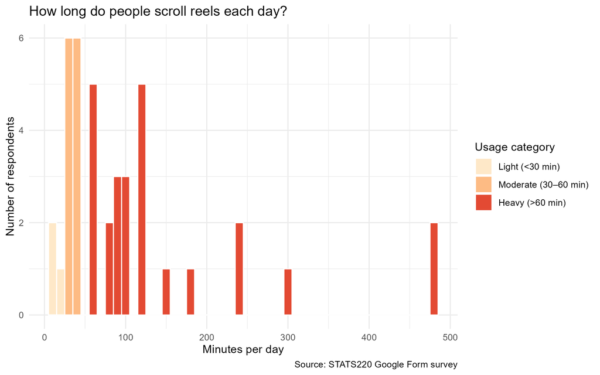

## Do unhappy users scroll more?

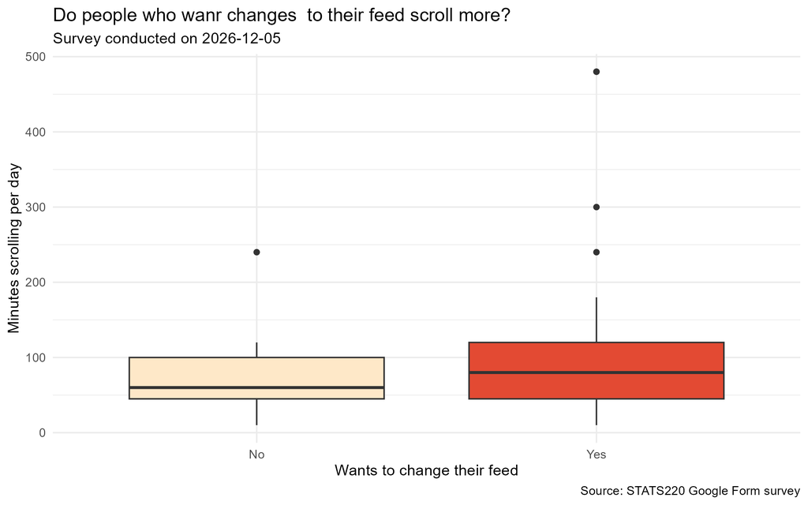

Boxplot comparing the daily scroll time between people who do/not want their feeds changed

This boxplot compares how long people scroll depending on whether they want changes to their feed. If dissatisfied users scroll more, it may suggest the algorithm keeps people engaged even when they find the content unsatisfying.

This boxplot compares how long people scroll, depending on whether they wish to change their feed or not. It can be inferred that if people who arent satisified scroll more, the algorithm can keep them engaged when they find said content they arent satisified with